# stat4990_pj

Koki Yamanaka

2023-11-30

## Introduction

- The Dow Jones Industrial Average (^DJI) is a price-weighted index that tracks 30 large, public companies trading on the New York Stock Exchange and the Nasdaq. In a way, it represents the overall market and the largest sectors of U.S. economy. most expensive stocks on the index (UNH. HD, GS)
- DJI current prices of 30 stocks make up index are added then divided by dow divisor.

## imports

```r
library(quantmod) # download from yahoo
library(dplyr) # pipe operator
library(tsibble)
```

```r
library(ggplot2) # autoplot
library(tidyverse)
library(fable) # model()
library(feasts) # model()

# install.packages('patchwork')
library(patchwork) # combine 2 plots
```

## Data preparation (tsibble)

```r
# Download data from yahoo Finance!
# extract 3 years as train set and 2 months as test
start.date = '2020-10-01'     # starting date of stock
end.date = '2023-11-28'       # ending date of stock

# Download the selected stocks from Yahoo finance using `quantmod` package
getSymbols("^DJI", src = "yahoo", from = start.date, to = end.date, auto.assign = TRUE)
```

```
## [1] "DJI"
```

```r
getSymbols("V", src = "yahoo", from = start.date, to = end.date, auto.assign = TRUE)
```

```
## [1] "V"
```

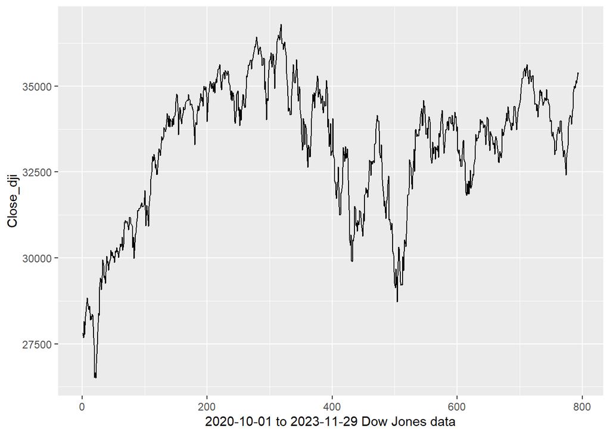

```r
# take close price
DJI = DJI$DJI.Close
V = V$V.Close

# Create date variable and rename a few columns
DJI <- zoo::fortify.zoo(DJI)
DJI <- DJI %>% rename(c("Date" = "Index", "Close_dji" = "DJI.Close"))
Visa <- zoo::fortify.zoo(V)
Visa <- Visa %>% rename(c("Date" = "Index", "Close_visa" = "V.Close"))

# merge DJI AND Visa in df zoo object
data <- merge(DJI,Visa)

# create a tsibble assign Date column as time index
data <- as_tsibble(data, index = Date)

# create a new column to assign a unique row number to each row,, relocate unique row number to the front
data <- data |>
  mutate(day = row_number()) |>
  update_tsibble(index = day, regular = TRUE) |>
  relocate(day)

# plot the close price of both
data |> autoplot(Close_dji) +   labs(x = "2020-10-01 to 2023-11-29 Dow Jones data")
```

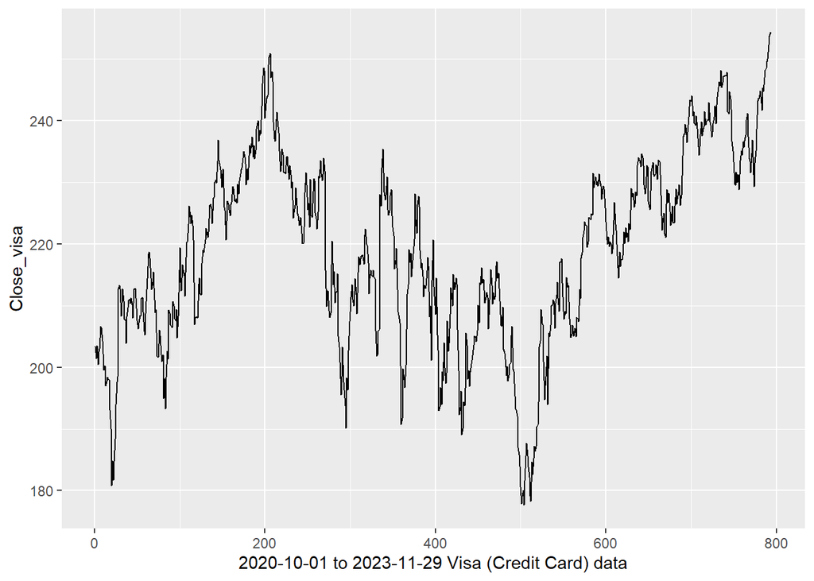

```r
data |> autoplot(Close_visa) +   labs(x = "2020-10-01 to 2023-11-29 Visa (Credit Card) data")
```

We see the plot are quite similar to each other. Note, visa accounts for 4% of dow jones index.

## Exploration

```r
# normalize 2 closing prices using minmaxscaler
data <- data %>% # for dji
  mutate(normalize.close.dji = (Close_dji - min(Close_dji)) / (max(Close_dji) - min(Close_dji)))
data <- data %>% # for visa
  mutate(normalize.close.visa = (Close_visa - min(Close_visa)) / (max(Close_visa) - min(Close_visa)))

data
```

```
## # A tsibble: 794 x 6 [1]
##      day Date       Close_dji Close_visa normalize.close.dji
##    <int> <date>         <dbl>      <dbl>               <dbl>
##  1     1 2020-10-01    27817.       203.               0.128
##  2     2 2020-10-02    27683.       201.               0.115
##  3     3 2020-10-05    28149.       204.               0.160
##  4     4 2020-10-06    27773.       200.               0.123
##  5     5 2020-10-07    28303.       202.               0.175
##  6     6 2020-10-08    28426.       203.               0.187
##  7     7 2020-10-09    28587.       207.               0.202
##  8     8 2020-10-12    28838.       206.               0.227
##  9     9 2020-10-13    28680.       204.               0.212
## 10    10 2020-10-14    28514        202.               0.195
## # ℹ 784 more rows
## # ℹ 1 more variable: normalize.close.visa <dbl>
```

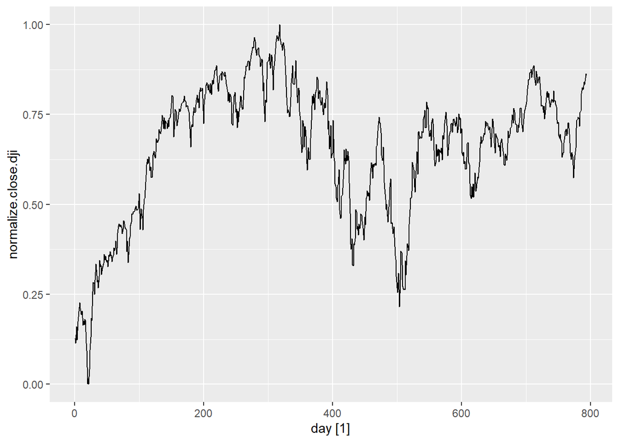

```r
data |> autoplot(normalize.close.dji)
```

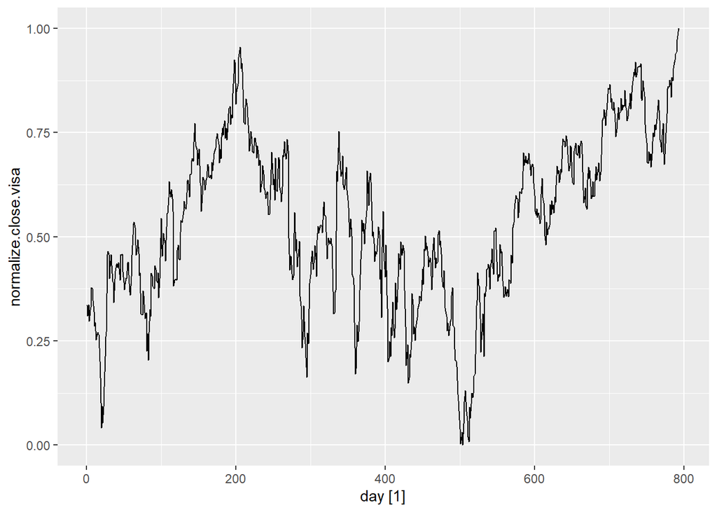

```r
data |> autoplot(normalize.close.visa)
```

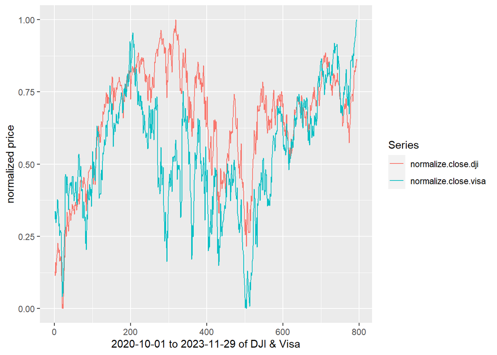

```r
data |>
  pivot_longer(c(normalize.close.dji, normalize.close.visa), names_to="Series") |>
  autoplot(value) +
  labs(y = "normalized price") +
  labs(x = "2020-10-01 to 2023-11-29 of DJI & Visa")
```

The moving pattern are quite similar.

## Correlation analysis

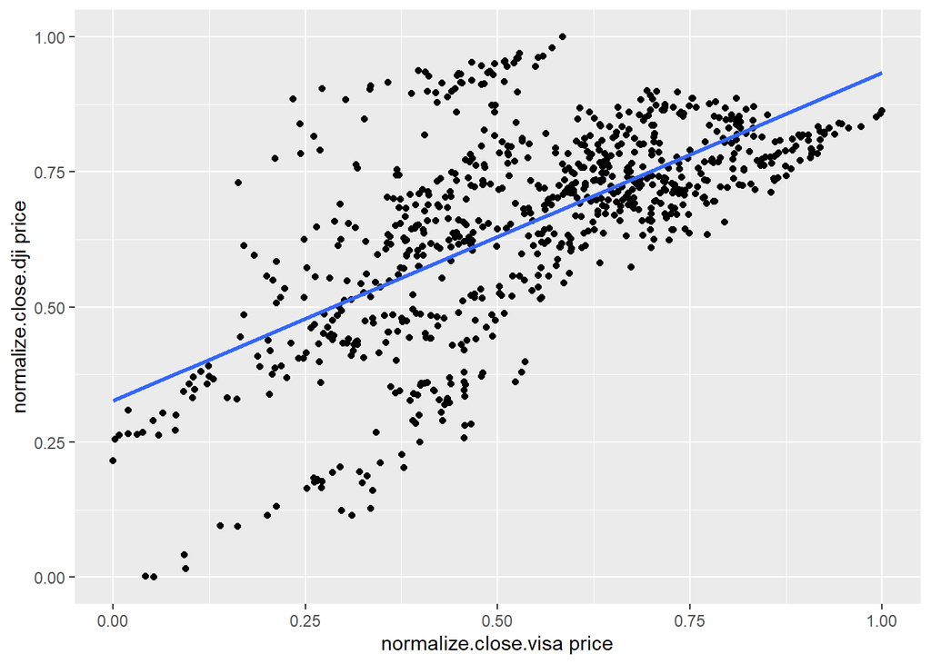

```r
# plot normalize.close.visa vs normalize.close.dji
data %>%
  ggplot(aes(x = normalize.close.visa, y = normalize.close.dji)) +
  labs(y = "normalize.close.dji price",
  x = "normalize.close.visa price") +
  geom_point() + geom_smooth(method = "lm", se = FALSE)
```

There is a positive correlation between visa and dji. Overall data follows homoscedasticity, but bottom left has some heteroscedasticity.

## train/test split

```r
# filter train set
train_dow_jones <- data |>
  filter(between(Date, as.Date("2020-10-01"), as.Date("2023-09-30")))
# filter test set
test_dow_jones <- data  |>
  filter(between(Date, as.Date("2023-10-01"), as.Date("2023-11-29")))
# note : weekends observation is omitted.
```

# Linear regression

## Fit a time series linear regression model

```r
 # Fit a time series linear regression model with close_visa as predictors
fit_cons <- train_dow_jones %>%
  model(lm = TSLM(Close_dji ~ Close_visa))
# report the results
report(fit_cons)
```

```
## Series: Close_dji
## Model: TSLM
##
## Residuals:
##      Min       1Q   Median       3Q      Max
## -4128.81  -812.22   -51.23   826.25  4349.57
##
## Coefficients:
##              Estimate Std. Error t value Pr(>|t|)
## (Intercept) 14253.175    789.864   18.05   <2e-16 ***
## Close_visa     87.005      3.619   24.04   <2e-16 ***
## ---
## Signif. codes:  0 '***' 0.001 '**' 0.01 '*' 0.05 '.' 0.1 ' ' 1
##
## Residual standard error: 1496 on 752 degrees of freedom
## Multiple R-squared: 0.4346,  Adjusted R-squared: 0.4338
## F-statistic:   578 on 1 and 752 DF, p-value: < 2.22e-16
```

## Plot fit model on actual observations

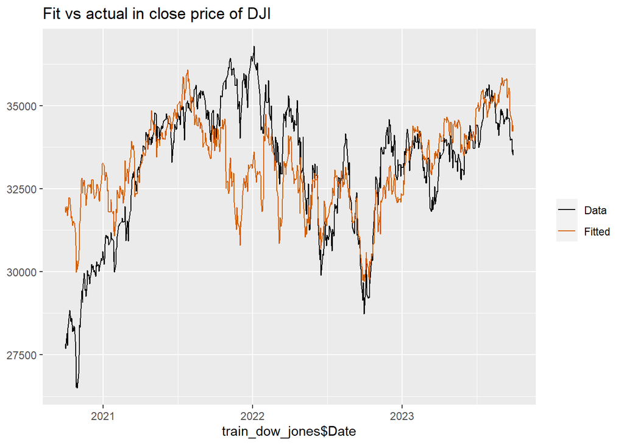

```r
augment(fit_cons) |>
  ggplot(aes(x = train_dow_jones$Date)) +
  geom_line(aes(y = Close_dji, colour = "Data")) +
  geom_line(aes(y = .fitted, colour = "Fitted")) +
  labs(y = NULL,
    title = "Fit vs actual in close price of DJI"
  ) +
  scale_colour_manual(values=c(Data="black",Fitted="#D55E00")) +
  guides(colour = guide_legend(title = NULL))
```

our model somehow fit the actual observations. notice, is exact visa price

## Check residuals

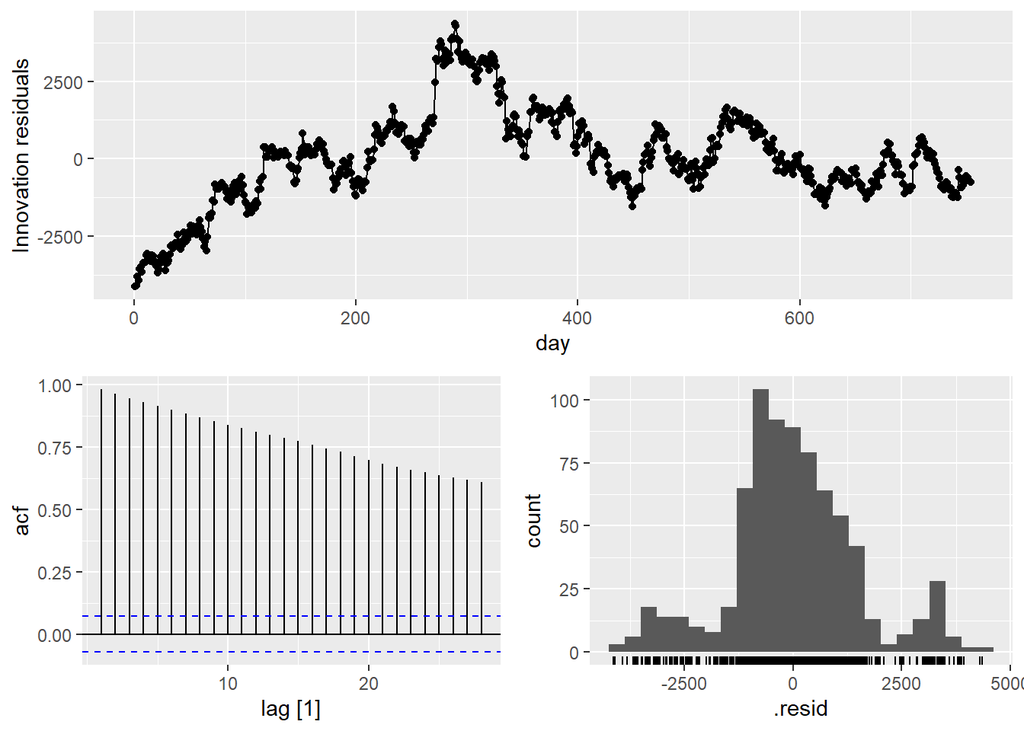

```r
fit_cons %>% gg_tsresiduals()
```

# Dynamic regression

Recall : a regression model with other predictors and errors are correlated. correlated errors capture past sequences to improve accuracy.

dynamic regression models used for better capturing information left in the residuals from linear regression. ## fit

```r
# Fit a dynamic regression model and visa close as predictor
fit_lr_sarima <- train_dow_jones %>%
  model(ARIMA(Close_dji ~ Close_visa))

# report the results
report(fit_lr_sarima)
```

```
## Series: Close_dji
## Model: LM w/ ARIMA(0,1,0) errors
##
## Coefficients:
##       Close_visa
##          66.0573
## s.e.      2.4694
##
## sigma^2 estimated as 51719:  log likelihood=-5154.33
## AIC=10312.66   AICc=10312.68   BIC=10321.91
```

- we see dynamic’s coefficient is 66.05 which is less than static regression. This implies dynamic allocate more weights to the series in close_dji itself rather than the predictors.
- best fitted is ARIMA(0,1,0) errors. This suggests residuals/unexplained variability in the our Dow Jones index follows a random walk. This reflect back to our actual observation.

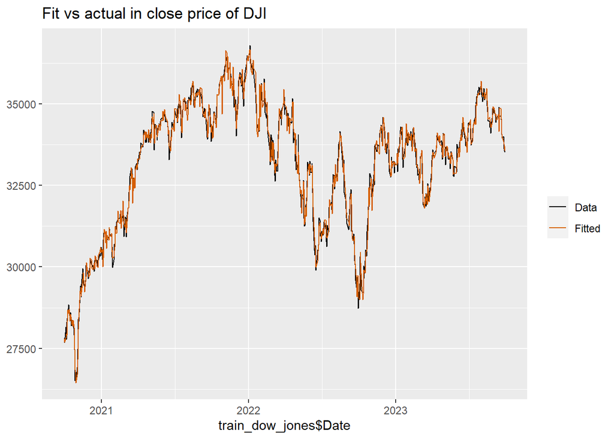

```r
augment(fit_lr_sarima) |>
  ggplot(aes(x = train_dow_jones$Date)) +
  geom_line(aes(y = Close_dji, colour = "Data")) +
  geom_line(aes(y = .fitted, colour = "Fitted")) +
  labs(y = NULL,
    title = "Fit vs actual in close price of DJI"
  ) +
  scale_colour_manual(values=c(Data="black",Fitted="#D55E00")) +
  guides(colour = guide_legend(title = NULL))
```

## residual check (compare with static and dynamic regression)

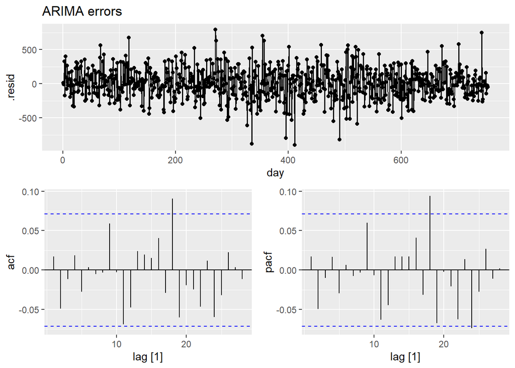

```r
# plot residuals for dynamic regression
residuals(fit_lr_sarima, type='innovation') %>%
gg_tsdisplay(.resid, plot_type = 'partial') +
labs(title = "ARIMA errors")
```

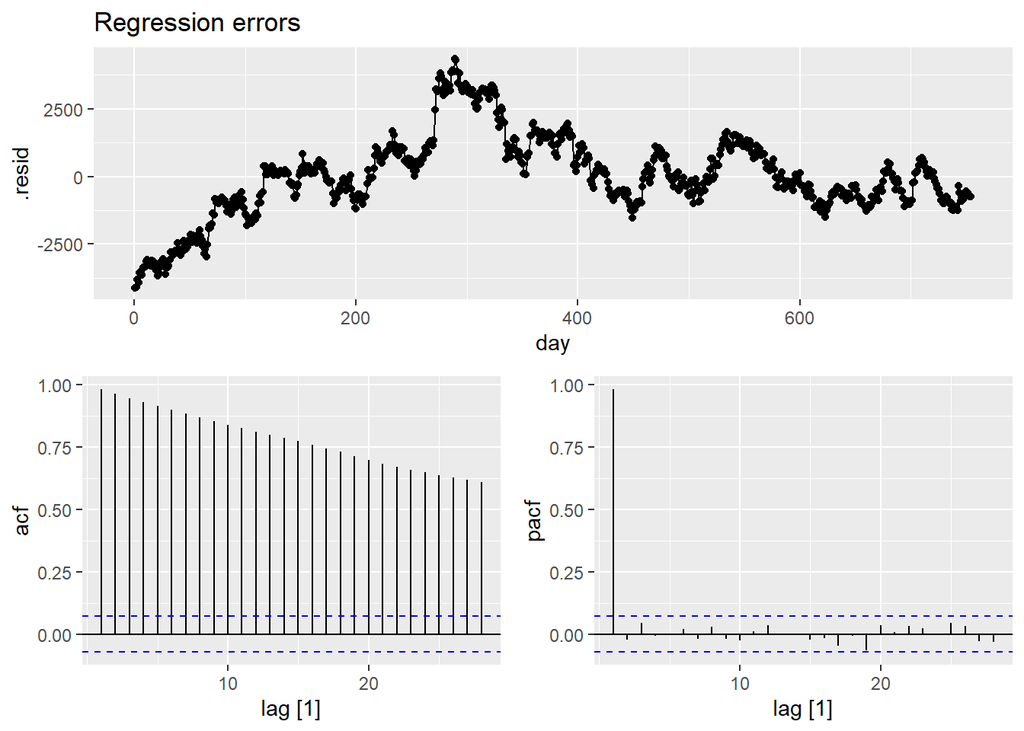

```r
# plot residuals for static regression
residuals(fit_cons, type='innovation') %>%
gg_tsdisplay(.resid, plot_type = 'partial') +
labs(title = "Regression errors")
```

Residuals : In ARIMA errors, residuals are bounded around 0 in overall, which captures patterns in our index well.

From these inspect, dynamic model has captures adequate autocorrelations for DJI than static.

## forecast and plot

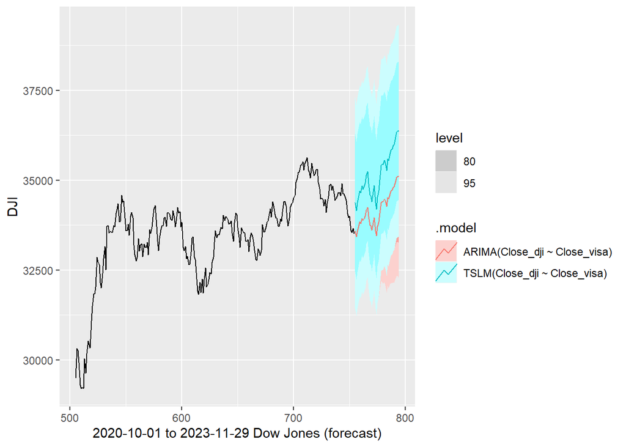

```r
# shorten the dataset to capture forecast plot better
data_for_plot <- data |>
  filter(between(Date, as.Date("2022-10-01"), as.Date("2023-09-30")))

# fit 2 models on train set
fit_2model <- train_dow_jones %>%
  model(
    ARIMA(Close_dji ~ Close_visa),
    TSLM(Close_dji ~ Close_visa)
    )
# forecast 2 models on test set
forecast_2model <- forecast(fit_2model,test_dow_jones)


# plot forecast on most recent period
forecast_2model |>
  autoplot (data_for_plot) +
  xlab("2020-10-01 to 2023-11-29 Dow Jones (forecast)") +
  ylab("DJI")
```

```
## Plot variable not specified, automatically selected `.vars = Close_dji`
```

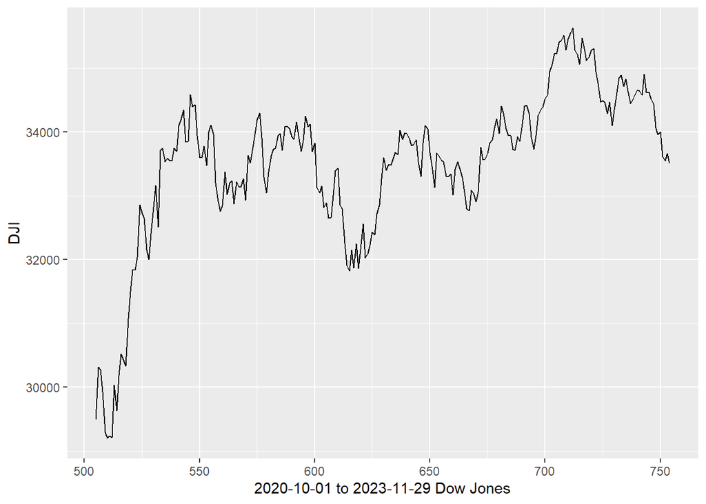

```r
# plot original data
autoplot (data_for_plot) +
  xlab("2020-10-01 to 2023-11-29 Dow Jones") +
  ylab("DJI")
```

## accuracy

```r
# get accuracy for test set
accuracy(forecast_2model,data)
```

```
## # A tibble: 2 × 10
##   .model                 .type     ME  RMSE   MAE    MPE  MAPE  MASE RMSSE  ACF1
##   <chr>                  <chr>  <dbl> <dbl> <dbl>  <dbl> <dbl> <dbl> <dbl> <dbl>
## 1 ARIMA(Close_dji ~ Clo… Test   -301.  468.  401. -0.911  1.20  1.68  1.47 0.879
## 2 TSLM(Close_dji ~ Clos… Test  -1271. 1296. 1271. -3.77   3.77  5.33  4.08 0.802
```

ARIMA error has less RMSE than TSLM, thus RMSE is a better model. This implies TSlM fail to capture the dynamics in the actual observations.

## cross valiadation

```r
# extract the column needed to do cross-valid to avoid computation
train_dji <- train_dow_jones %>%
  select(Date,Close_dji,Close_visa)

# create cross validation set (creates 59,964 new data, 114 unique set)
cv_stocks <- train_dji |>
  stretch_tsibble(.init = 200, .step = 2)

# check accuracy on cross validation
fit.arima.cv <- cv_stocks |>      # arima error
  model(ARIMA(Close_dji ~ Close_visa))
fit.tslm.cv <- cv_stocks |>       # linear regression
  model(TSLM(Close_dji ~ Close_visa))

# get accuracy
acrc_arima <- fit.arima.cv |> accuracy()
acrc_tslm <- fit.tslm.cv |> accuracy()

# get mean of RMSE
mean(acrc_arima$RMSE)
```

```
## [1] 222.5977
```

```r
mean(acrc_tslm$RMSE)
```

```
## [1] 1623.184
```

```r
## accuracy for train set
# fit 2 models on train set
fit_2model |> accuracy()
```

```
## # A tibble: 2 × 10
##   .model             .type       ME  RMSE   MAE     MPE  MAPE  MASE RMSSE   ACF1
##   <chr>              <chr>    <dbl> <dbl> <dbl>   <dbl> <dbl> <dbl> <dbl>  <dbl>
## 1 ARIMA(Close_dji ~… Trai… 5.23e+ 0  227.  174.  0.0146 0.526 0.728 0.716 0.0170
## 2 TSLM(Close_dji ~ … Trai… 2.47e-13 1494. 1112. -0.215  3.40  4.66  4.71  0.982
```